# Deterministic Interpolation: IDW

Luke Ghallahorne

2024-05-10

```r
library(tidyverse)
library(sf)
library(gstat)
library(terra)
library(tidyterra)
library(PNWColors)
```

```r
# function to turn sf to raster
sf_2_rast <-function(sfObject,variableIndex = 1){
  # coerce sf to a data.frame
  dfObject <- data.frame(st_coordinates(sfObject),
                         z=as.data.frame(sfObject)[,variableIndex])
  # coerce data.frame to SpatRaster
  rastObject <- rast(dfObject,crs=crs(sfObject))

  names(rastObject) <- names(sfObject)[variableIndex]

  return(rastObject)
}
```

# Data

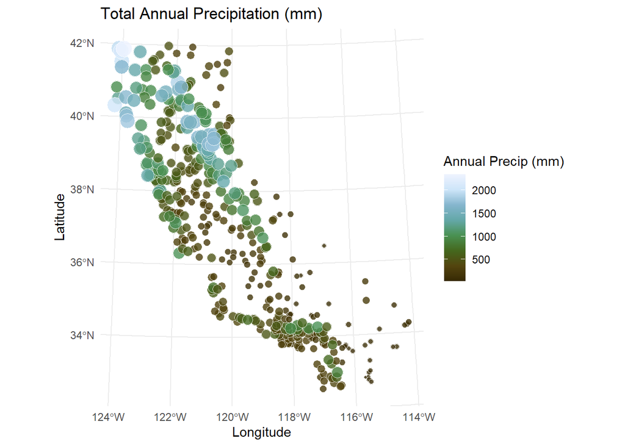

```r
# load data

# grid point data
gridCA <- readRDS("data/gridCA.rds")
# precipitation point data
prcpCA <- readRDS("data/prcpCA.rds")

# make as sf
prcpCA_sf <- prcpCA |>
  st_as_sf(coords = c("X", "Y")) |>
  st_set_crs(value = 3310)
gridCA_sf <- gridCA |>
  st_as_sf(coords = c("X", "Y")) |>
  st_set_crs(value = 3310)

pal1 <- pnw_palette("Lake", n = nrow(prcpCA))

# simple map
prcpCA_sf |> ggplot() +
  geom_sf(aes(fill = ANNUAL, size = ANNUAL), color = "white",
          shape = 21, alpha = 0.8) +
  scale_fill_gradientn(colors = (pal1),
                        name = "Annual Precip (mm)",
                        na.value = "transparent") +
  labs(title = "Total Annual Precipitation (mm)") +
  scale_size(guide = "none") +
  xlab("Longitude") + ylab("Latitude") +
  theme_minimal()
```

The original data are point data including coordinates and annual precipitation averages at 432 points across the state of California. I will use Inverse Distance Weighting (IDW) to deterministically interpolate the annual precipitation across the entire state at a resolution of 10km by 10km.

# IDW Test Maps

Excluding 25% of points to test for goodness of fit ($R^2$) and error (Root Mean Square Error):

## p = 1

### Interpolation Map

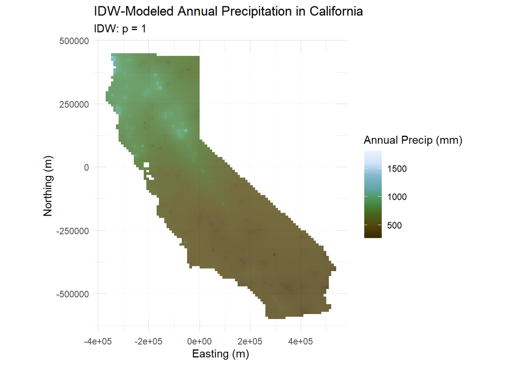

```r
set.seed(42)
n <- nrow(prcpCA_sf)
rows4test <- sample(x = 1:n,size = n*0.25)
prcpTest <- prcpCA_sf[rows4test,]
prcpTrain <- prcpCA_sf[-rows4test,]

# build the model with prcpTrain
idw_test <- gstat(formula=ANNUAL~1,
                      locations = prcpTrain,
                      set=list(idp = 1))
idw_test_sf <- predict(idw_test, gridCA_sf, debug.level = 0)

# annual precipitation p = 1 raster
prcp_rast <- sf_2_rast(idw_test_sf)
# prcp_p1_rast

# precipitation plot p = 1
ggplot() +
  geom_raster(data = prcp_rast,
              mapping = aes(x = x, y = y,
                            fill = var1.pred), alpha = 0.8) +
  scale_fill_gradientn(colors = (pal1),
                        name = "Annual Precip (mm)",
                        na.value = "transparent") +
  labs(title = "IDW-Modeled Annual Precipitation in California",
       subtitle = "IDW: p = 1") +
  xlab("Easting (m)") +
  ylab("Northing (m)") +
  coord_equal() +
  theme_minimal()
```

### Goodness of Fit

```r
# assess skill
# observations
obs <- prcpTest$ANNUAL
# predictions
preds <- terra::extract(prcp_rast, prcpTest) |>
  pull(var1.pred)
# R^2
rsq <- cor(obs, preds, use="complete.obs")^2
rsq
```

```
## [1] 0.5550103
```

```r
# root mean square error
rmse <- sqrt(mean((preds - obs)^2, na.rm=TRUE))
rmse
```

```
## [1] 350.9792
```

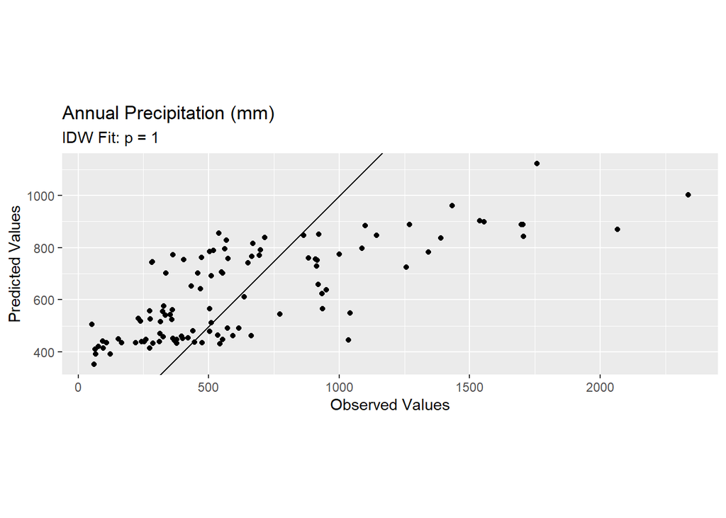

```r
ggplot() +
  geom_abline(slope=1,intercept = 0) +
  geom_point(aes(x = obs, y = preds),
             na.rm = TRUE) +
  coord_fixed(ratio = 1,
              xlim = range(preds, obs),
              ylim = range(preds,obs)) +
  labs(x="Observed Values",
       y="Predicted Values",
       title="Annual Precipitation (mm)",
       subtitle = "IDW Fit: p = 1")
```

## p = 2

### Interpolation Map

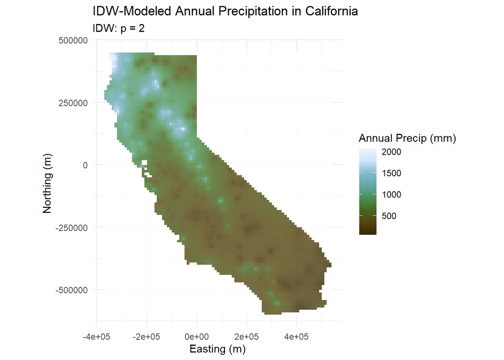

```r
# build the model with prcpTrain
idw_test <- gstat(formula=ANNUAL~1,
                      locations = prcpTrain,
                      set=list(idp = 2))
idw_test_sf <- predict(idw_test, gridCA_sf, debug.level = 0)

# annual precipitation p = 2 raster
prcp_rast <- sf_2_rast(idw_test_sf)
# prcp_p1_rast

# precipitation plot p = 2
ggplot() +
  geom_raster(data = prcp_rast,
              mapping = aes(x = x, y = y,
                            fill = var1.pred), alpha = 0.8) +
  scale_fill_gradientn(colors = (pal1),
                        name = "Annual Precip (mm)",
                        na.value = "transparent") +
  labs(title = "IDW-Modeled Annual Precipitation in California",
       subtitle = "IDW: p = 2") +
  xlab("Easting (m)") +
  ylab("Northing (m)") +
  coord_equal() +
  theme_minimal()
```

### Goodness of Fit

```r
# assess skill
# observations
obs <- prcpTest$ANNUAL
# predictions
preds <- terra::extract(prcp_rast, prcpTest) |>
  pull(var1.pred)
# R^2
rsq <- cor(obs, preds, use="complete.obs")^2
rsq
```

```
## [1] 0.7545653
```

```r
# root mean square error
rmse <- sqrt(mean((preds - obs)^2, na.rm=TRUE))
rmse
```

```
## [1] 238.7871
```

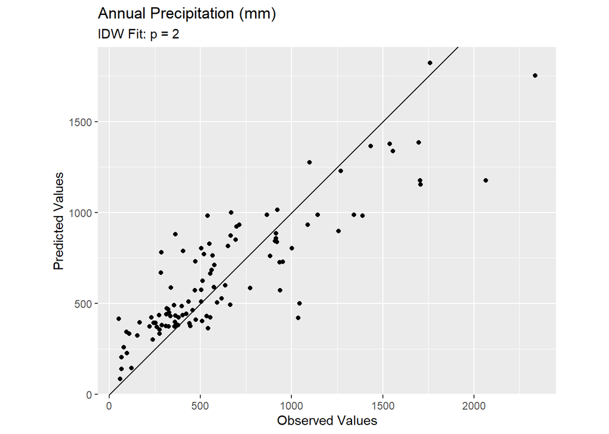

```r
ggplot() +
  geom_abline(slope=1,intercept = 0) +
  geom_point(aes(x = obs, y = preds),
             na.rm = TRUE) +
  coord_fixed(ratio = 1,
              xlim = range(preds, obs),
              ylim = range(preds,obs)) +
  labs(x="Observed Values",
       y="Predicted Values",
       title="Annual Precipitation (mm)",
       subtitle = "IDW Fit: p = 2")
```

## p = 3

### Interpolation Map

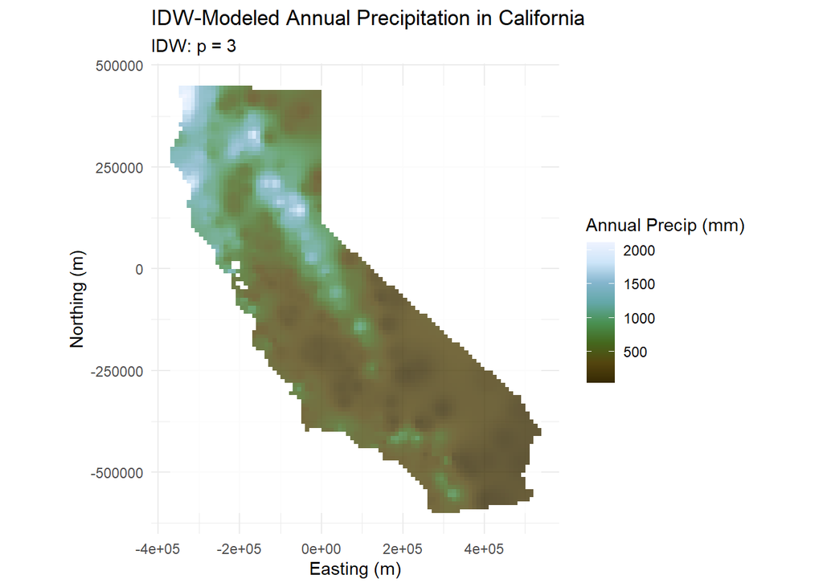

```r
# build the model with prcpTrain
idw_test <- gstat(formula=ANNUAL~1,
                      locations = prcpTrain,
                      set=list(idp = 3))
idw_test_sf <- predict(idw_test, gridCA_sf, debug.level = 0)

# annual precipitation p = 3 raster
prcp_rast <- sf_2_rast(idw_test_sf)
# prcp_p1_rast

# precipitation plot p = 3
ggplot() +
  geom_raster(data = prcp_rast,
              mapping = aes(x = x, y = y,
                            fill = var1.pred), alpha = 0.8) +
  scale_fill_gradientn(colors = (pal1),
                        name = "Annual Precip (mm)",
                        na.value = "transparent") +
  labs(title = "IDW-Modeled Annual Precipitation in California",
       subtitle = "IDW: p = 3") +
  xlab("Easting (m)") +
  ylab("Northing (m)") +
  coord_equal() +
  theme_minimal()
```

### Goodness of Fit

```r
# assess skill
# observations
obs <- prcpTest$ANNUAL
# predictions
preds <- terra::extract(prcp_rast, prcpTest) |>
  pull(var1.pred)
# R^2
rsq <- cor(obs, preds, use="complete.obs")^2
rsq
```

```
## [1] 0.8108699
```

```r
# root mean square error
rmse <- sqrt(mean((preds - obs)^2, na.rm=TRUE))
rmse
```

```
## [1] 202.7128
```

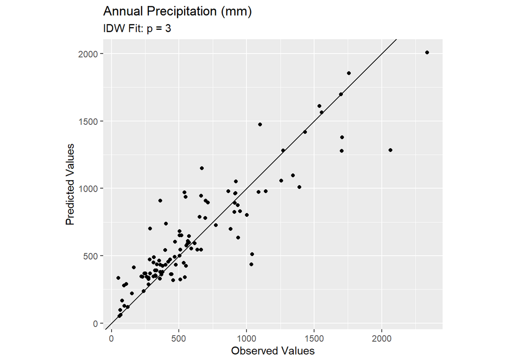

```r
ggplot() +
  geom_abline(slope=1,intercept = 0) +
  geom_point(aes(x = obs, y = preds),
             na.rm = TRUE) +
  coord_fixed(ratio = 1,
              xlim = range(preds, obs),
              ylim = range(preds,obs)) +
  labs(x="Observed Values",
       y="Predicted Values",
       title="Annual Precipitation (mm)",
       subtitle = "IDW Fit: p = 3")
```

## p = 4

### Interpolation Map

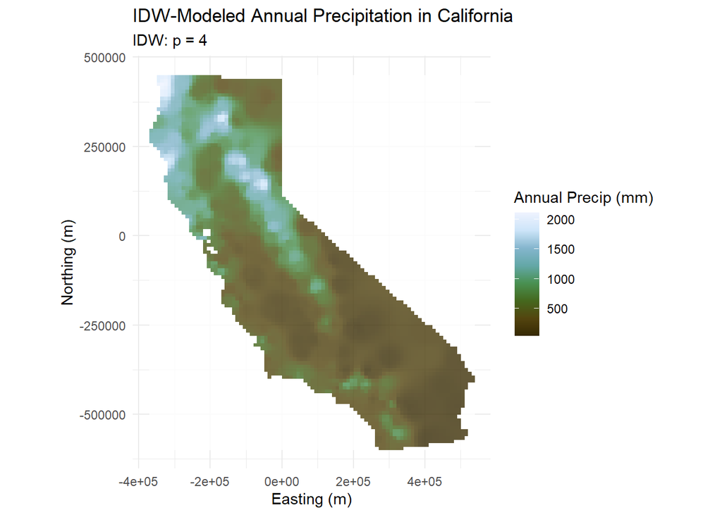

```r
# build the model with prcpTrain
idw_test <- gstat(formula=ANNUAL~1,
                      locations = prcpTrain,
                      set=list(idp = 4))
idw_test_sf <- predict(idw_test, gridCA_sf, debug.level = 0)

# annual precipitation p = 4 raster
prcp_rast <- sf_2_rast(idw_test_sf)
# prcp_p1_rast

# precipitation plot p = 4
ggplot() +
  geom_raster(data = prcp_rast,
              mapping = aes(x = x, y = y,
                            fill = var1.pred), alpha = 0.8) +
  scale_fill_gradientn(colors = (pal1),
                        name = "Annual Precip (mm)",
                        na.value = "transparent") +
  labs(title = "IDW-Modeled Annual Precipitation in California",
       subtitle = "IDW: p = 4") +
  xlab("Easting (m)") +
  ylab("Northing (m)") +
  coord_equal() +
  theme_minimal()
```

### Goodness of Fit

```r
# assess skill
# observations
obs <- prcpTest$ANNUAL
# predictions
preds <- terra::extract(prcp_rast, prcpTest) |>
  pull(var1.pred)
# R^2
rsq <- cor(obs, preds, use="complete.obs")^2
rsq
```

```
## [1] 0.816035
```

```r
# root mean square error
rmse <- sqrt(mean((preds - obs)^2, na.rm=TRUE))
rmse
```

```
## [1] 198.5668
```

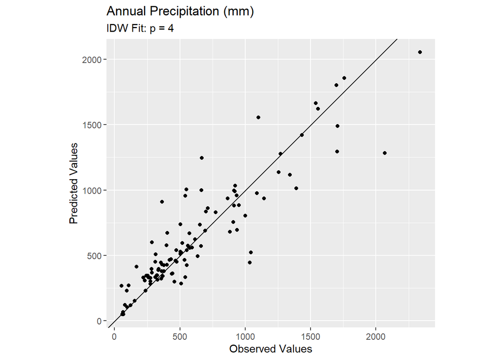

```r
ggplot() +
  geom_abline(slope=1,intercept = 0) +
  geom_point(aes(x = obs, y = preds),
             na.rm = TRUE) +
  coord_fixed(ratio = 1,
              xlim = range(preds, obs),
              ylim = range(preds,obs)) +
  labs(x="Observed Values",
       y="Predicted Values",
       title="Annual Precipitation (mm)",
       subtitle = "IDW Fit: p = 4")
```

## p = 5

### Interpolation Map

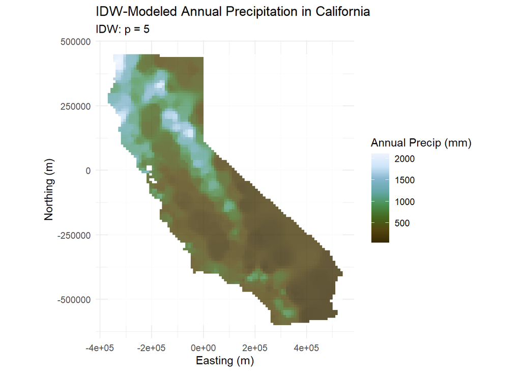

```r
# build the model with prcpTrain
idw_test <- gstat(formula=ANNUAL~1,
                      locations = prcpTrain,
                      set=list(idp = 5))
idw_test_sf <- predict(idw_test, gridCA_sf, debug.level = 0)

# annual precipitation p = 5 raster
prcp_rast <- sf_2_rast(idw_test_sf)
# prcp_p1_rast

# precipitation plot p = 5
ggplot() +
  geom_raster(data = prcp_rast,
              mapping = aes(x = x, y = y,
                            fill = var1.pred), alpha = 0.8) +
  scale_fill_gradientn(colors = (pal1),
                        name = "Annual Precip (mm)",
                        na.value = "transparent") +
  labs(title = "IDW-Modeled Annual Precipitation in California",
       subtitle = "IDW: p = 5") +
  xlab("Easting (m)") +
  ylab("Northing (m)") +
  coord_equal() +
  theme_minimal()
```

### Goodness of Fit

```r
# assess skill
# observations
obs <- prcpTest$ANNUAL
# predictions
preds <- terra::extract(prcp_rast, prcpTest) |>
  pull(var1.pred)
# R^2
rsq <- cor(obs, preds, use="complete.obs")^2
rsq
```

```
## [1] 0.8118306
```

```r
# root mean square error
rmse <- sqrt(mean((preds - obs)^2, na.rm=TRUE))
rmse
```

```
## [1] 200.7657
```

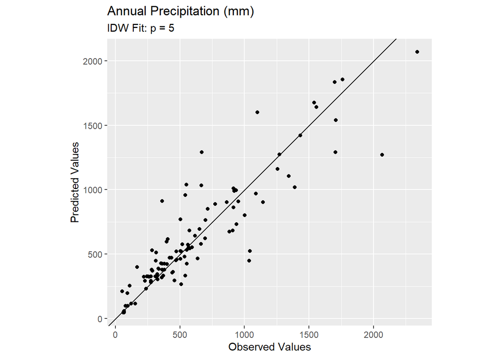

```r
ggplot() +
  geom_abline(slope=1,intercept = 0) +
  geom_point(aes(x = obs, y = preds),
             na.rm = TRUE) +
  coord_fixed(ratio = 1,
              xlim = range(preds, obs),
              ylim = range(preds,obs)) +
  labs(x="Observed Values",
       y="Predicted Values",
       title="Annual Precipitation (mm)",
       subtitle = "IDW Fit: p = 5")
```